# IODS course project

Atte Keltanen

# About the project

After completing this course I will understand the principles and advantages of using open research tools with open data and understand the possibilities of reproducible research. I will know how to use R, R Studio, R markdown, and GitHub for these tasks and also know how to learn more of these open software tools. I will also know how to apply certain statistical methods of data science, that is, data-driven statistics.

[My project repository](https://github.com/lex/iods-project)

# Week 2: Analysis of the students2014 data

## The dataset

The data was collected for studying a relationship between academic achievement and different factors. The most interesting ones are about studying behavior.

The data was collected during the second part of the course *Introduction to Social Statistics*, fall 2014, held by Kimmo Vehkalahti at the University of Helsinki, Finland.

*(n=183, 67% female, mean age 25.6 years, 77.6% social science students)*

```r
str(learning2014)
```

```
## 'data.frame':    166 obs. of  7 variables:
##  $ gender  : Factor w/ 2 levels "F","M": 1 2 1 2 2 1 2 1 2 1 ...
##  $ age     : int  53 55 49 53 49 38 50 37 37 42 ...
##  $ attitude: num  3.7 3.1 2.5 3.5 3.7 3.8 3.5 2.9 3.8 2.1 ...
##  $ deep    : num  3.58 2.92 3.5 3.5 3.67 ...
##  $ stra    : num  3.38 2.75 3.62 3.12 3.62 ...
##  $ surf    : num  2.58 3.17 2.25 2.25 2.83 ...
##  $ points  : int  25 12 24 10 22 21 21 31 24 26 ...
```

```r
dim(learning2014)
```

```
## [1] 166   7
```

The data contains 166 observations and seven variables.

## Overview of the data

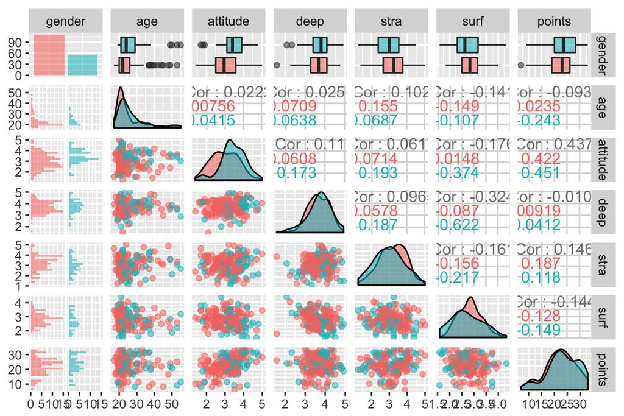

```r
p <- ggpairs(learning2014, mapping = aes(col=gender, alpha=0.3), lower = list(combo = wrap("facethist", bins = 20)))

p
```

The scatter plot doesn’t reveal much, except that there is a pretty high correlation between attitude and exam points (0.437) compared to everything else. We’ll take a look at that later.

#### Gender

```r
summary(learning2014$gender)
```

```
##   F   M
## 110  56
```

- 110 female participants, 56 male
- About double the female participants compared to male students

#### Age

```r
summary(learning2014$age)
```

```
##    Min. 1st Qu.  Median    Mean 3rd Qu.    Max.
##   17.00   21.00   22.00   25.51   27.00   55.00
```

- The youngest participant was only 17 years old
- The oldest participant was 55 years old
- The median age was 22 years

#### Attitude

```r
summary(learning2014$attitude)
```

```
##    Min. 1st Qu.  Median    Mean 3rd Qu.    Max.
##   1.400   2.600   3.200   3.143   3.700   5.000
```

- On the Likert scale (1-5)
- Attitudes seem pretty neutral (median attitude of 3.2)

#### 1st learning approach: Deep Learning

```r
summary(learning2014$deep)
```

```
##    Min. 1st Qu.  Median    Mean 3rd Qu.    Max.
##   1.583   3.333   3.667   3.680   4.083   4.917
```

- On a Likert scale (1-5)
- Seems like the most common learning style (highest median of the learning styles)

#### 2nd learning approach: Surface Learning

```r
summary(learning2014$surf)
```

```
##    Min. 1st Qu.  Median    Mean 3rd Qu.    Max.
##   1.583   2.417   2.833   2.787   3.167   4.333
```

- On a Likert scale (1-5)
- Seems like the most uncommon learning style (lowest median of the learning styles)

#### 3rd learning approach: Strategic Learning

```r
summary(learning2014$stra)
```

```
##    Min. 1st Qu.  Median    Mean 3rd Qu.    Max.
##   1.250   2.625   3.188   3.121   3.625   5.000
```

- On a Likert scale (1-5)
- Seems like the most average learning method

#### Exam Points

```r
summary(learning2014$points)
```

```
##    Min. 1st Qu.  Median    Mean 3rd Qu.    Max.
##    7.00   19.00   23.00   22.72   27.75   33.00
```

- Maximum achieved points were 33
- Minimum were 7
- Median points were 23

## Regression model

The goal is to find a correlation between exam points and some variables. I picked age, attitude and strategic learning.

```r
model <- lm(points ~ age + attitude + stra, data=learning2014)
summary(model)
```

```
##
## Call:
## lm(formula = points ~ age + attitude + stra, data = learning2014)
##
## Residuals:
##      Min       1Q   Median       3Q      Max
## -18.1149  -3.2003   0.3303   3.4129  10.7599
##
## Coefficients:
##             Estimate Std. Error t value Pr(>|t|)
## (Intercept) 10.89543    2.64834   4.114 6.17e-05 ***
## age         -0.08822    0.05302  -1.664   0.0981 .
## attitude     3.48077    0.56220   6.191 4.72e-09 ***
## stra         1.00371    0.53434   1.878   0.0621 .
## ---
## Signif. codes:  0 '***' 0.001 '**' 0.01 '*' 0.05 '.' 0.1 ' ' 1
##
## Residual standard error: 5.26 on 162 degrees of freedom
## Multiple R-squared:  0.2182, Adjusted R-squared:  0.2037
## F-statistic: 15.07 on 3 and 162 DF,  p-value: 1.07e-08
```

Age does not seem to fit in the model very well. I expected using strategic learning to have some effect on the points achieved, but it turned out to be not statistically significant. Only attitude seems to be relevant, so that’s what we’ll use in our next and final model:

```r
model <- lm(points ~ attitude, data=learning2014)
summary(model)
```

```
##
## Call:
## lm(formula = points ~ attitude, data = learning2014)
##
## Residuals:
##      Min       1Q   Median       3Q      Max
## -16.9763  -3.2119   0.4339   4.1534  10.6645
##
## Coefficients:
##             Estimate Std. Error t value Pr(>|t|)
## (Intercept)  11.6372     1.8303   6.358 1.95e-09 ***
## attitude      3.5255     0.5674   6.214 4.12e-09 ***
## ---
## Signif. codes:  0 '***' 0.001 '**' 0.01 '*' 0.05 '.' 0.1 ' ' 1
##
## Residual standard error: 5.32 on 164 degrees of freedom
## Multiple R-squared:  0.1906, Adjusted R-squared:  0.1856
## F-statistic: 38.61 on 1 and 164 DF,  p-value: 4.119e-09
```

Residuals tell the difference between observed values and the estimated values by the model. The median residual is pretty low at 0.4, but the minimum residual is pretty high. It tells us that the worst observed exam points were expected 17 points higher by the model. The same happens with maximum residual: the highest points were expected to be ten points lower.

The t value tells us the t test statistic. Higher t values are more significant to the model, but alone it doesn’t mean much, because it depends on the degrees of freedom. However the column *Pr(>|t|)* with the three stars (***) tells us that it’s statistically significant.

## Diagnostic plots

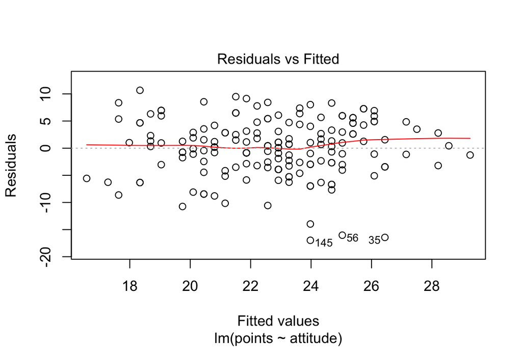

```r
plot(model, which=c(1))
```

Residuals vs fitted is used to detect non-linearity. If there would be visible patterns in our line, there could be a problem with our model. Our line is pretty straight, so our model seems fine.

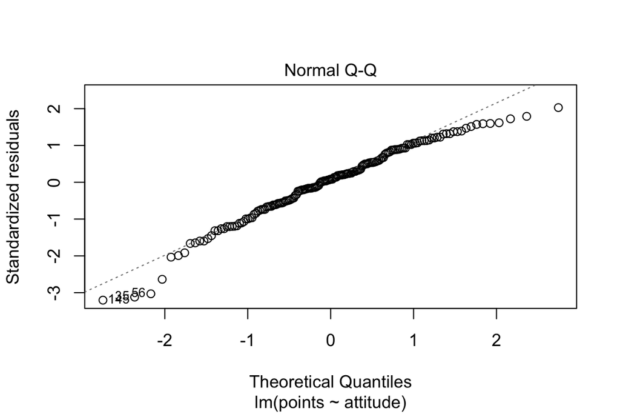

```r
plot(model, which=c(2))
```

Q-Q plot is used to check if the residuals of the model are normally distributed. Ideally all the points would be aligned to the dotted line. With our model the line from the points is a bit curved, but still pretty close to the ideal line.

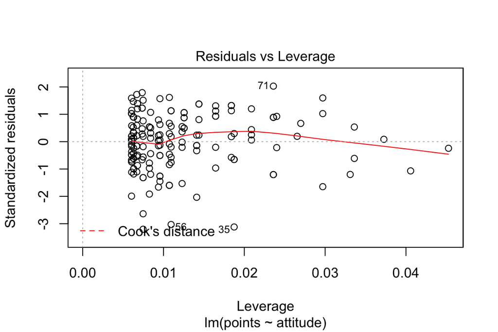

```r
plot(model, which=c(5))
```

This plot tells if there are influential cases which could affect the regression line. In our model there seems to be none, since there even aren’t any Cook’s lines visible in the plot.

### References:

http://www.helsinki.fi/~kvehkala/JYTmooc/JYTOPKYS3-meta.txt

http://www.slideshare.net/kimmovehkalahti/the-relationship-between-learning-approaches-and-students-achievements-in-an-introductory-statistics-course-in-finland

# Week 3: Analysis of the alcohol use data

## The dataset

There is a lot of background information about the participants, for example their father’s and mother’s jobs, travel times to school and such.

Obligatory citation from the original data: *Using Data Mining To Predict Secondary School Student Alcohol Consumption. Fabio Pagnotta, Hossain Mohammad Amran Department of Computer Science,University of Camerino*

```r
colnames(alcohol_use)
```

```
##  [1] "school"     "sex"        "age"        "address"    "famsize"
##  [6] "Pstatus"    "Medu"       "Fedu"       "Mjob"       "Fjob"
## [11] "reason"     "nursery"    "internet"   "guardian"   "traveltime"
## [16] "studytime"  "failures"   "schoolsup"  "famsup"     "paid"
## [21] "activities" "higher"     "romantic"   "famrel"     "freetime"
## [26] "goout"      "Dalc"       "Walc"       "health"     "absences"
## [31] "G1"         "G2"         "G3"         "alc_use"    "high_use"
```

```r
dim(alcohol_use)
```

```
## [1] 382  35
```

The data contains 382 observations and 35 variables.

## Relationships between high and low alcohol consumption

#### 1. Time spent on studying per week

I’m expecting lower study time to mean a higher alcohol consumption.  
The codes you will see later have the following meaning:  
*1 - <2 hours, 2 - 2 to 5 hours, 3 - 5 to 10 hours, or 4 - >10 hours*

#### 2. Address type

I’m expecting people living in cities to use more alcohol. Living areas are coded as follows: ‘U’ - urban or ‘R’ - rural.

#### 3. Sex

I’m expecting men to have a higher alcohol use.

#### 4. Going out with friends

I’m expecting going out more to increase alcohol use. The answers range from 1 (very low) to 5 (very high).

### Some plots

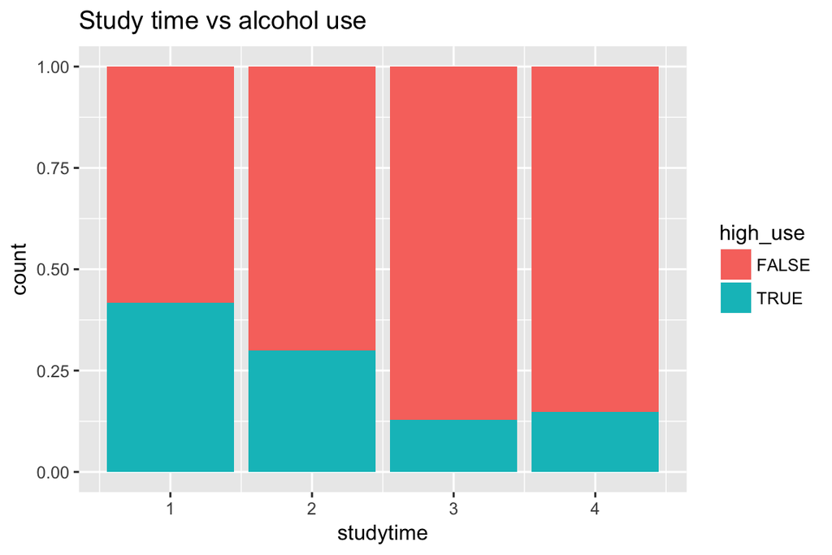

```r
ggplot(alcohol_use, aes(x = studytime, fill = high_use)) + geom_bar(position = "fill") + ggtitle("Study time vs alcohol use")
```

Spending less time on studies seems to have an increasing effect on alcohol consumption.

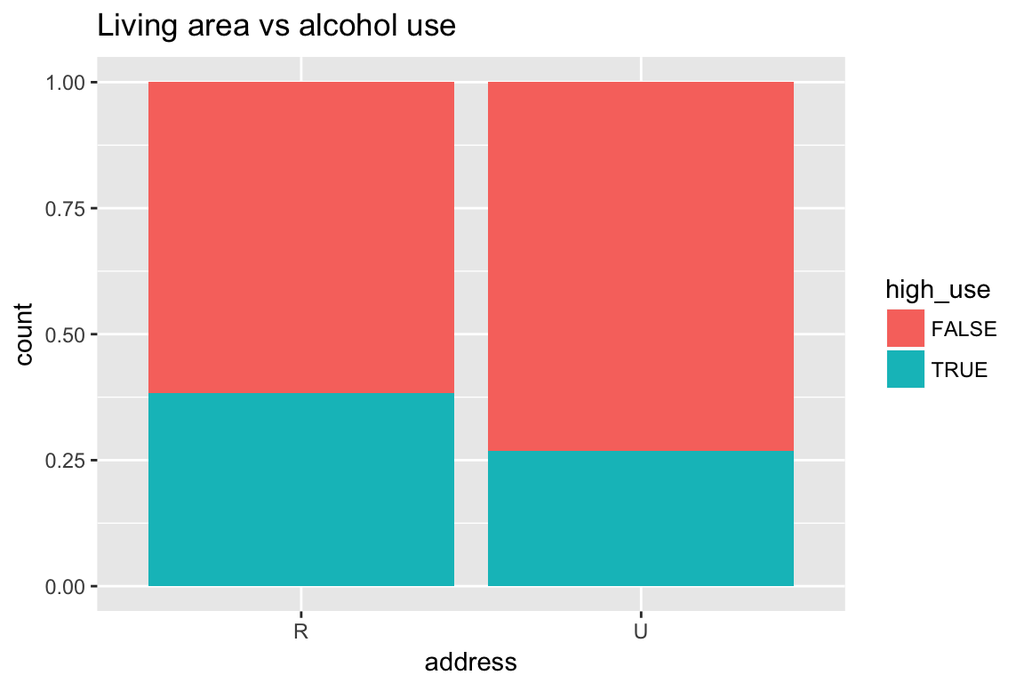

```r
ggplot(alcohol_use, aes(x = address, fill = high_use)) + geom_bar(position = "fill") + ggtitle("Living area vs alcohol use")
```

I was expecting students living in urban areas (U) to drink more, but it seems like rural (R) students drink more. The difference is not that great, but that’s something to look at.

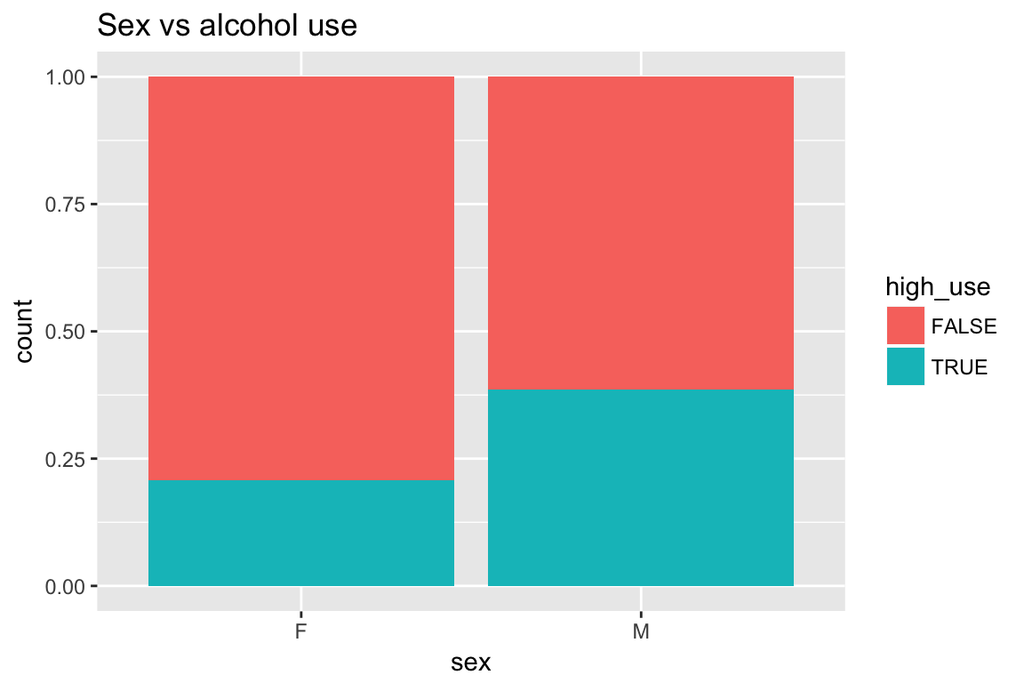

```r
ggplot(alcohol_use, aes(x = sex, fill = high_use)) + geom_bar(position = "fill") + ggtitle("Sex vs alcohol use")
```

It seems like men are more likely to consume more alcohol than their female counterparts.

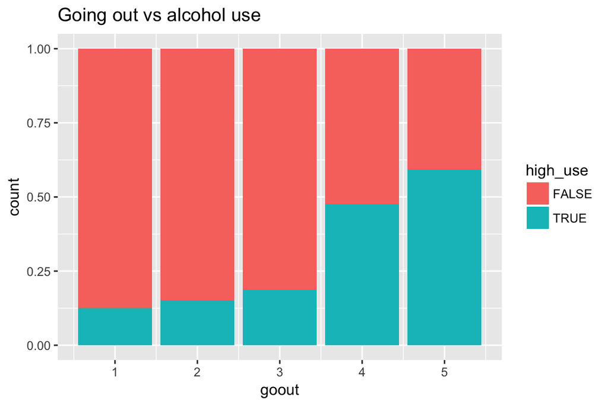

```r
ggplot(alcohol_use, aes(x = goout, fill = high_use)) + geom_bar(position = "fill") + ggtitle("Going out vs alcohol use")
```

Looks like high alcohol use rises with the frequency of going out pretty significantly.

## Logistic regression

```r
m <- glm(high_use ~ studytime + address + sex + goout, data = alcohol_use, family = "binomial")
summary(m)
```

```
##
## Call:
## glm(formula = high_use ~ studytime + address + sex + goout, family = "binomial",
##     data = alcohol_use)
##
## Deviance Residuals:
##     Min       1Q   Median       3Q      Max
## -1.7687  -0.7949  -0.4701   0.7707   2.4382
##
## Coefficients:
##             Estimate Std. Error z value Pr(>|z|)
## (Intercept)  -2.1747     0.6014  -3.616   0.0003 ***
## studytime    -0.5060     0.1699  -2.978   0.0029 **
## addressU     -0.7734     0.3021  -2.560   0.0105 *
## sexM          0.6512     0.2638   2.469   0.0136 *
## goout         0.7730     0.1196   6.462 1.04e-10 ***
## ---
## Signif. codes:  0 '***' 0.001 '**' 0.01 '*' 0.05 '.' 0.1 ' ' 1
##
## (Dispersion parameter for binomial family taken to be 1)
##
##     Null deviance: 462.21  on 381  degrees of freedom
## Residual deviance: 383.57  on 377  degrees of freedom
## AIC: 393.57
##
## Number of Fisher Scoring iterations: 4
```

Living area and sex have some effect, but not as much as the frequency of going out or time spent on studying. Going out seems to have the most effect.

```r
OR <- coef(m) %>% exp
CI <- confint(m) %>% exp
cbind(OR, CI)
```

```
##                    OR      2.5 %    97.5 %
## (Intercept) 0.1136447 0.03397617 0.3612755
## studytime   0.6028828 0.42771567 0.8343182
## addressU    0.4614355 0.25463666 0.8355741
## sexM        1.9179216 1.14615394 3.2310521
## goout       2.1661707 1.72470400 2.7596110
```

The odds ratios seems to indicate that being male and going out give the highest odds of experiencing a high alcohol consumption. The confidence values for them are high though. Judging by them it seems like time spent on studying and living in urban areas would make high alcohol use more unlikely than being a male and going out more to make it more likely.

```r
probabilities <- predict(m, type = "response")

# add the predicted probabilities to 'alcohol_use'
alcohol_use <- mutate(alcohol_use, probability = probabilities)

# use the probabilities to make a prediction of high_use
alcohol_use <- mutate(alcohol_use, prediction = probability > 0.5)

# tabulate the target variable versus the predictions
table(high_use = alcohol_use$high_use, prediction = alcohol_use$prediction) %>% prop.table() %>% addmargins()
```

```
##         prediction
## high_use      FALSE       TRUE        Sum
##    FALSE 0.66753927 0.03926702 0.70680628
##    TRUE  0.18324607 0.10994764 0.29319372
##    Sum   0.85078534 0.14921466 1.00000000
```

```r
loss_func <- function(class, prob) {
  n_wrong <- abs(class - prob) > 0.5
  mean(n_wrong)
}
loss_func(class = alcohol_use$high_use, prob = alcohol_use$probability)
```

```
## [1] 0.2225131
```

```r
cv <- cv.glm(data = alcohol_use, cost = loss_func, glmfit = m, K = 10)
cv$delta[1]
```

```
## [1] 0.2251309
```

22.2% error on model, ~23% error on the cross validation depending on the run. It would seem like my model has a better performance compared to the model in DataCamp (26%).

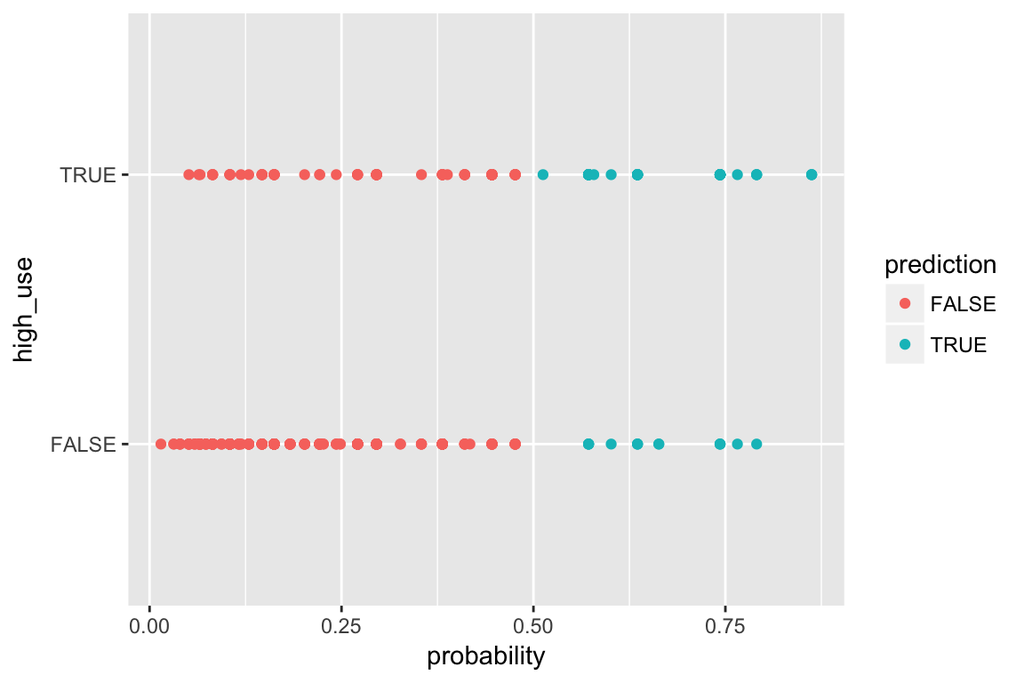

```r
# initialize a plot of 'high_use' versus 'probability' in 'alc'
g <- ggplot(alcohol_use, aes(x = probability, y = high_use, col = prediction))

# define the geom as points and draw the plot
g + geom_point()
```

### References

https://archive.ics.uci.edu/ml/datasets/STUDENT+ALCOHOL+CONSUMPTION